# Filtering euka03

Adeline Stewart<sup>1,2,3</sup>, Delphine Rioux<sup>3</sup>, Fréderic Boyer<sup>3</sup>, Ludovic Gielly<sup>3</sup>, François Pompanon<sup>3</sup>, Amélie Saillard<sup>3</sup>, Wilfried Thuiller<sup>3</sup>, The ORCHAMP Consortium, Jean-Gabriel Valay<sup>2</sup>, Eric Maréchal<sup>1,@</sup>, and Eric Coissac<sup>3,@</sup>

<sup>1</sup> Univ. Grenoble Alpes, CEA, CNRS, INRAE, IRIG, Laboratoire de Physiologie Cellulaire & Végétale, 38000 Grenoble.  
<sup>2</sup> Univ. Grenoble-Alpes, CNRS, Jardin du Lautaret, 38000, Grenoble, France.  
<sup>3</sup> Univ. Grenoble-Alpes, Univ. Savoie Mont Blanc, CNRS, LECA, 38000, Grenoble, France.

<sup>@</sup> Correspondence: Eric Maréchal <eric.marechal@cea.fr>, Eric Coissac <eric.coissac@metabarcoding.org>

Go back to the global description of the project

# 1 Setting up the R environment

```
- `ROBITools` package is used to read result files produced by OBITools.
- `ROBITaxonomy` package provides function allowing to query OBITools formated taxonomy.
```

```r
if (!require(ROBITools)) {

  # ROBITools are not available on CRAN and have to be installed
  # from http://git.metabarcoding.org using devtools

  if (!require(devtools)) {
    install.packages("devtools")
  }

  devtools::install_git("https://git.metabarcoding.org/obitools/ROBIUtils.git")
  devtools::install_git("https://git.metabarcoding.org/obitools/ROBITaxonomy.git")
  devtools::install_git("https://git.metabarcoding.org/obitools/ROBITools.git")

  library(ROBITools)
}

library(ROBITaxonomy)
```

- `tidyverse` provides various method for efficient data manipulation and plotting via `ggplot2`

```r
if (!require(tidyverse)) {
  install.packages("tidyverse")
  library(tidyverse)
}
```

- `vegan` is loaded for its `decostand` function

```r
if (!require(vegan)) {
  install.packages("vegan")
  library(vegan)
}
```

- `ade4` provides multivariate analysis functions

```r
if (!require(ade4)) {
  install.packages("ade4")
  library(ade4)
}
```

# 2 Loading an preparing of the dataset

## 2.1 Loading of the OBITools formated NCBI taxonomy

```r
ncbi <- read.taxonomy("embl-140/ncbi20190930")
```

## 2.2 Loading the raw data after obitools processing

```r
euka03_raw = import.metabarcoding.data("euka03/euka03.ecotag.tab")
```

## 2.3 Extract the obiclean data from the MOTU description.

```r
euka03_raw.clean <- extracts.obiclean(euka03_raw)
rm(euka03_raw)
```

## 2.4 Affects categories to the samples among

```r
sample_names <- rownames(euka03_raw.clean)
positive_control <- grep(pattern = "^CPOS[0-9]+-", x = sample_names)
negative_control <- grep(pattern = "^CNEG[0-9]+-", x = sample_names)
control <- grep(pattern = "^C[0-9]+-", x = sample_names)
blanks <- grep(pattern = "^emptyDNA[0-9]+-", x = sample_names)
category <- factor(rep("sample", nrow(euka03_raw.clean)),
  levels = c("sample", "positive_ctrl", "negative_ctrl", "blank","control")
)
category[positive_control] <- "positive_ctrl"
category[negative_control] <- "negative_ctrl"
category[blanks] <- "blank"
category[control] <- "control"

euka03_raw.clean@samples$category <- category
```

## 2.5 Adds a sample id that corresponds to the PCR id (sample_name column) without the replica id

```r
sampleid = sapply(sample_names, function(x) strsplit(x,split = "_")[[1]][1])
sampleid = str_replace(sampleid,"-2016","")
euka03_raw.clean@samples$sampleid <- factor(sampleid)
```

## 2.6 Adds information about sites

```r
site <- factor(category, levels = c(
  levels(category),
  "ANT", "CHA", "LOR", "RIS", "VCH"
))

for (s in c("ANT", "CHA", "LOR", "RIS", "VCH")) {
  p <- grep(pattern = paste0("^", s, "[0-9]+-"), x = sample_names)
  site[p] <- s
}

euka03_raw.clean@samples$site <- site
```

Plots for every PCR its diversity as a function of read counts

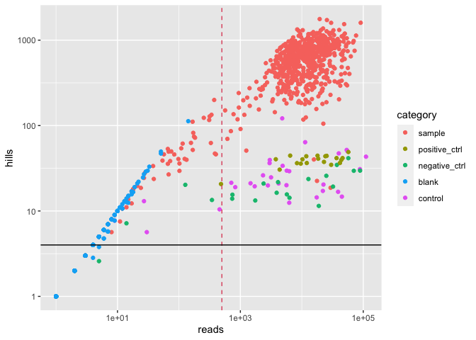

```r
euka03_raw.clean %>% plot_reads_x_motus(q = 1, threshold = 0.00, limit = 500) +
geom_hline(yintercept = 4)
```

## 2.7 Filters out sequences that are not considered as true sequences by obiclean

```r
# Sets the count of not true sequences to 0.
euka03_raw.center <- euka03_raw.clean
euka03_raw.center@reads[euka03_raw.clean$obiclean_status != "h"] <- 0

# Removes MOTUs occurring in any samples
euka03_raw.center <- euka03_raw.center[, colSums(euka03_raw.center@reads) > 0]

# Removes empty samples
euka03_raw.center <- euka03_raw.center[which(rowSums(euka03_raw.center@reads) > 0), ]

# Erases the original large data set
rm(euka03_raw.clean)
```

## 2.8 Adds a taxo_group column to the MOTU description with three categories :

- eukaryota
- Others
- Not annoted

The `Not annoted` category corresponds to MOTU without similarity with the reference database. The ’Others" category corresponds to non *eukaryota* MOTUs.

```r
motus_cat <- rep("Others",ncol(euka03_raw.center))

eukaryota.taxid <- ecofind(ncbi,"^eukaryota$")
is_eukaryota <- is.subcladeof(ncbi,euka03_raw.center@motus$taxid, eukaryota.taxid)
motus_cat[is_eukaryota] <- "Eukaryota"
motus_cat[euka03_raw.center@motus$taxid == 1] <- "Not annoted"

euka03_raw.center@motus$taxo_group <- factor(motus_cat,
                                             levels = c("Eukaryota","Others","Not annoted"))
```

Plot for each PCR then hill’s number diversity for $q=1$ as a function of read numbers associated to that PCR.

The theoritical Hill’s number for positive controle is $^1D=4$.

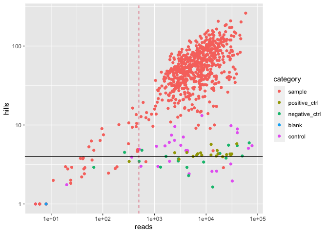

```r
euka03_raw.center %>% plot_reads_x_motus(q=1,threshold = 0.00,limit = 500) +
                      geom_hline(yintercept = 4)
```

## 2.9 Look for contaminents

### 2.9.1 Look for sequences present in negative PCR controles and samples

```r
euka03_in_negative_ctrls <- which(
                             colSums(
                               euka03_raw.center@reads[
                                 euka03_raw.center@samples$category == "negative_ctrl",
                                 ]) > 0)

maxneg <- aggregate(euka03_raw.center[,euka03_in_negative_ctrls],
               MARGIN = 1,
               by = list(category = euka03_raw.center@samples$category),
               FUN = max
              )
neg_ctrls <- data.frame(
  sample   = colSums(euka03_raw.center@reads[euka03_raw.center@samples$category == "sample",
                                             euka03_in_negative_ctrls]),
  positive = colSums(euka03_raw.center@reads[euka03_raw.center@samples$category == "positive_ctrl",
                                             euka03_in_negative_ctrls]),
  negative = colSums(euka03_raw.center@reads[euka03_raw.center@samples$category == "negative_ctrl",
                                             euka03_in_negative_ctrls]),
  max_in   = rownames(maxneg@reads)[apply(maxneg@reads,2,which.max)],
  idx      = euka03_in_negative_ctrls)

neg_ctrls
```

|  | sample | positive | negative | max_in | idx |
| --- | --- | --- | --- | --- | --- |
| HISEQ:269:CAUGPANXX:3:1101:14351:43638_CONS_SUB_SUB_CMP | 0 | 0 | 86 | negative_ctrl | 189 |
| HISEQ:269:CAUGPANXX:3:1106:16003:23373_CONS_SUB_SUB_CMP | 21 | 0 | 95 | control | 220 |
| HISEQ:269:CAUGPANXX:3:1101:10887:46113_CONS_SUB_SUB | 0 | 0 | 5061 | negative_ctrl | 265 |
| HISEQ:269:CAUGPANXX:3:1111:20405:31615_CONS_SUB_SUB | 0 | 0 | 29 | negative_ctrl | 309 |
| HISEQ:269:CAUGPANXX:3:1206:17092:74384_CONS_SUB_SUB | 0 | 0 | 115 | negative_ctrl | 414 |
| HISEQ:269:CAUGPANXX:3:1204:8565:52177_CONS_SUB_SUB | 0 | 0 | 123 | negative_ctrl | 542 |
| HISEQ:269:CAUGPANXX:3:1106:12916:65271_CONS_SUB_SUB_CMP | 22 | 0 | 545 | negative_ctrl | 662 |
| HISEQ:269:CAUGPANXX:3:1101:10057:40154_CONS_SUB_SUB_CMP | 76 | 0 | 11 | control | 730 |
| HISEQ:269:CAUGPANXX:3:1101:1168:10222_CONS_SUB_SUB_CMP | 1017 | 0 | 10020 | negative_ctrl | 810 |
| HISEQ:269:CAUGPANXX:3:2209:20545:69094_CONS_SUB_SUB_CMP | 0 | 0 | 8 | negative_ctrl | 887 |

[output cut: 81 more lines]

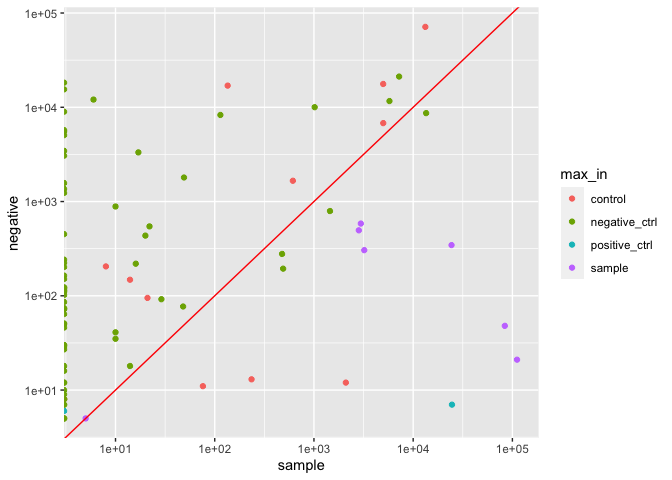

```r
neg_ctrls %>% ggplot(aes(x = sample, y = negative, col = max_in)) +
  geom_point() +
  scale_x_log10() +
  scale_y_log10() +
  geom_abline(slope = 1, intercept = 0, col = "red")
```

#### 2.9.1.1 Remove a potentiol contaminent from negative controle

Each MOTU more abundant in the negative controls than in the samples is removed.

```r
euka03_raw.center <- euka03_raw.center[,-(neg_ctrls[neg_ctrls$max_in == "negative_ctrl","idx"])]
```

Clean the dataset by removing every empty PCR

```r
euka03_raw.center <- euka03_raw.center[which(rowSums(euka03_raw.center@reads) > 0),]
dim(euka03_raw.center)
```

```
## [1]  737 8948
```

## 2.10 Number of replicate per PCR category

Counts how many PCR replicates are conserved at that level of the analysis.

```r
n_pcr = table(euka03_raw.center@samples$sampleid)[as.character(euka03_raw.center@samples$sampleid)]
table(n_pcr,euka03_raw.center@samples$site)
```

```
##
## n_pcr sample positive_ctrl negative_ctrl blank control ANT CHA LOR RIS VCH
##     1      0             0             1     1       1   0   0   0   0   1
##     2      0             0             0     0       6   0   0   0   2   6
##     3      0            12             9     0       6   6   0   6   9  27
##     4      0             8             8     0      16 136 144 136 128  68
```

## 2.11 Filters out PCR replicats with too few reads

Plots for every PCR its diversity as a function of read counts

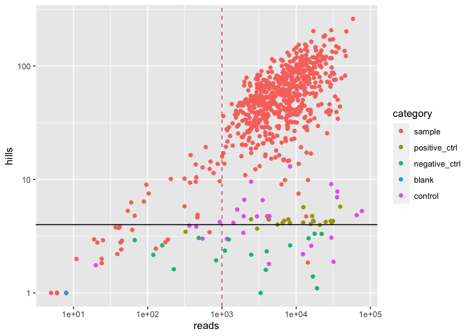

```r
euka03_raw.center %>% plot_reads_x_motus(q=1,threshold = 0.00,limit = 1000) + geom_hline(yintercept = 4)
```

Keeps only PCRs with more than 1000 reads. MOTUs having no more representants are removed

```r
euka03_raw.center <- euka03_raw.center[rowSums(euka03_raw.center@reads) >=1000,]
euka03_raw.center <- euka03_raw.center[,colSums(euka03_raw.center@reads) >0]
```

Keeps only PCRs having a diversity greater than 10. MOTUs having no more representants are removed

```r
euka03_raw.center <- euka03_raw.center[apply(euka03_raw.center@reads,1,D_q) >= 10,]
euka03_raw.center <- euka03_raw.center[,colSums(euka03_raw.center@reads) >0]
```

## 2.12 Checks similarity between PCR replicates

```r
euka03.keep1 = tag_bad_pcr(euka03_raw.center@samples$sampleid,
                           counts = euka03_raw.center@reads
                          )
```

[figure not shown]

```r
euka03_by_taxo_group <- aggregate(euka03_raw.center,MARGIN = 2,by = list(euka03_raw.center@motus$taxo_group),FUN = sum)
```

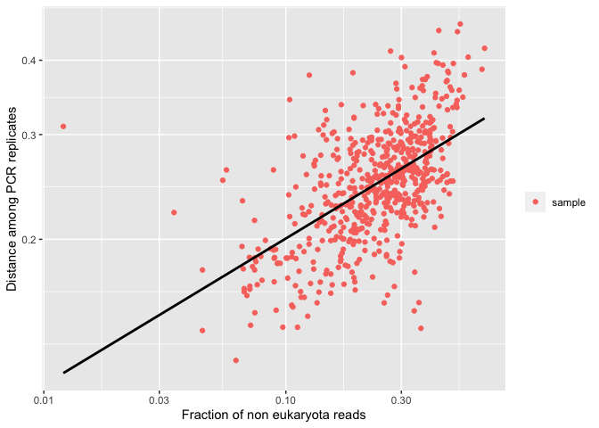

```r
data = data.frame(x = euka03.keep1$distance,
                  y = 1 - euka03_by_taxo_group@reads[,1]/rowSums(euka03_by_taxo_group@reads),
                  col=euka03_raw.center@samples$category,
                  pch=as.character(table(euka03_raw.center@samples$sampleid)[as.character(euka03_raw.center@samples$sampleid)]),
                  ok = table(euka03_raw.center@samples$sampleid)[as.character(euka03_raw.center@samples$sampleid)] > 1 &
                              euka03_raw.center@samples$category == "sample")

ggplot(data[table(euka03_raw.center@samples$sampleid)[as.character(euka03_raw.center@samples$sampleid)] > 1,],aes(x=y,y=x,col=col)) +
  geom_point() +
  scale_x_log10() +
  scale_y_log10() +
  ylab("Distance among PCR replicates") +
  xlab("Fraction of non eukaryota reads") +
  stat_smooth(data = data[data$ok,],col="black",method="lm",se = FALSE) +
  theme(legend.title = element_blank())
```

```r
ok <- table(euka03_raw.center@samples$sampleid)[as.character(euka03_raw.center@samples$sampleid)] > 1 &
      euka03_raw.center@samples$category == "sample" & data$x > 0 & data$y > 0

l <- lm(log(data$x[ok]) ~ log(data$y[ok]),na.action = na.omit)
summary(l)
```

```
##
## Call:
## lm(formula = log(data$x[ok]) ~ log(data$y[ok]), na.action = na.omit)
##
## Residuals:
##      Min       1Q   Median       3Q      Max
## -0.66407 -0.11341 -0.01303  0.10700  0.95488
##
## Coefficients:
##                 Estimate Std. Error t value Pr(>|t|)
## (Intercept)     -1.03958    0.02250  -46.21   <2e-16 ***
## log(data$y[ok])  0.24611    0.01454   16.92   <2e-16 ***
## ---
## Signif. codes:  0 '***' 0.001 '**' 0.01 '*' 0.05 '.' 0.1 ' ' 1
##
## Residual standard error: 0.1807 on 606 degrees of freedom
## Multiple R-squared:  0.3209, Adjusted R-squared:  0.3198
## F-statistic: 286.4 on 1 and 606 DF,  p-value: < 2.2e-16
```

```r
cor(log(data$x[ok]) , log(data$y[ok]),use = "complete.obs")^2
```

```
## [1] 0.3209126
```

More eukaryota reads in the PCR closer are the replicates. The eukaryota amount of DNA seems to be the limitant factor.

## 2.13 Preprares the final data set for ecological analysis

We now just focus on the target group and remove every control PCRs

```r
euka03.eukaryota <- euka03_raw.center[,euka03_raw.center@motus$taxo_group == "Eukaryota"]
euka03.eukaryota <- euka03.eukaryota[which(rowSums(euka03.eukaryota@reads)>0),]
euka03.eukaryota <- euka03.eukaryota[which(euka03.eukaryota@samples$category=="sample"),]
euka03.eukaryota <- euka03.eukaryota[,which(colSums(euka03.eukaryota@reads)>0)]
```

and we merge the sites metadata

```r
orchamp_env <- read.csv("orchamp_env.csv",header = TRUE)
sample_descr <- read.csv2("labels_metabar_trie.csv",header = TRUE)
code_plot <- paste(sample_descr$Site_short,sample_descr$Altitude,sample_descr$Horizon,sep = "_")
sample_descr$Code_plot <- code_plot
left_join(sample_descr,orchamp_env) %>% right_join(euka03.eukaryota@samples %>% mutate(sampleid=str_replace(sampleid,"-2016","")),by = c(EXTRACTION.CODE="sampleid")) -> samples
rownames(samples) <- as.character(samples$sample)
euka03.eukaryota@samples <- samples

euka03.eukaryota@motus$class <- taxonatrank(ncbi,euka03.eukaryota@motus$taxid,"class",name=TRUE)
```

```r
table(table(euka03.eukaryota@samples$EXTRACTION.CODE)[as.character(euka03.eukaryota@samples$EXTRACTION.CODE)],euka03.eukaryota@samples$Site_short)
```

```
##
##     ANT CHA LOR RIS VCH
##   1   0   0   0   2   6
##   2   0   0   2   4  12
##   3  12  12  18  33  15
##   4 128 128 112  80  52
```

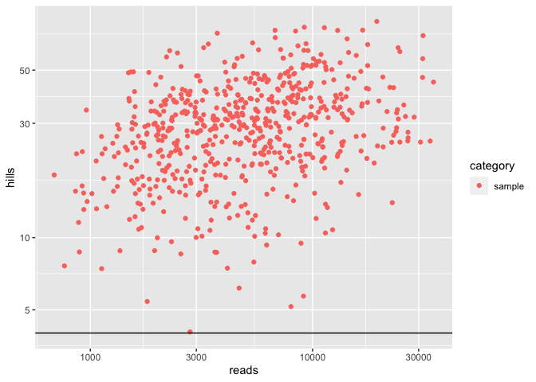

```r
euka03.eukaryota %>% plot_reads_x_motus(q=1,threshold = 0.00) + geom_hline(yintercept = 4)
```

Annotates sequences with useful taxonomy groups

- *Fungi*
- *Chlorophyta* (not belonging *Chlorophyceae* or *Trebouxiophyceae*)
  - *Chlorophyceae*
  - *Trebouxiophyceae*
- *Streptophyta* (Vascular plants)

```r
motus_cat <- rep("Others Eukaryota",ncol(euka03.eukaryota))

chlorophyta.taxid <- ecofind(ncbi,"^Chlorophyta$")
streptophyta.taxid <- ecofind(ncbi,"^Streptophyta$")
chlorophyceae.taxid <- ecofind(ncbi,"^Chlorophyceae$")
trebouxiophyceae.taxid <- ecofind(ncbi,"^Trebouxiophyceae$")
fungi.taxid <- ecofind(ncbi,"^Fungi$")


motus_cat[is.subcladeof(ncbi,euka03.eukaryota@motus$taxid, fungi.taxid)] <- "Fungi"
motus_cat[is.subcladeof(ncbi,euka03.eukaryota@motus$taxid, streptophyta.taxid)] <- "Streptophyta"
motus_cat[is.subcladeof(ncbi,euka03.eukaryota@motus$taxid, chlorophyta.taxid)] <- "Other Chlorophyta"
motus_cat[is.subcladeof(ncbi,euka03.eukaryota@motus$taxid, chlorophyceae.taxid)] <- "Chlorophyceae"
motus_cat[is.subcladeof(ncbi,euka03.eukaryota@motus$taxid, trebouxiophyceae.taxid)] <- "Trebouxiophyceae"

euka03.eukaryota@motus$taxo_group <- factor(motus_cat,
                                             levels = c("Fungi","Streptophyta",
                                                        "Chlorophyceae","Trebouxiophyceae",
                                                        "Other Chlorophyta","Others Eukaryota"))

euka03_by_taxo_group <- aggregate(euka03.eukaryota,MARGIN = 2,by = list(euka03.eukaryota@motus$taxo_group),FUN = sum)
```

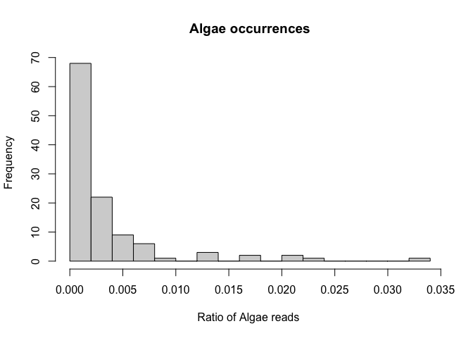

```r
algae_ratio <- apply(euka03_by_taxo_group@reads, MARGIN = 1, function(x) sum(x[3:5])/sum(x))
hist(algae_ratio[algae_ratio > 0],breaks = 20, xlab = "Ratio of Algae reads ", main = "Algae occurrences")
```

Precomputes the part of the taxonomic group into each PCR

```r
euka03.eukaryota@samples$fungi_part <-  apply(euka03_by_taxo_group@reads, MARGIN = 1, function(x) x[1]/sum(x))
euka03.eukaryota@samples$streptophyta_part <-  apply(euka03_by_taxo_group@reads, MARGIN = 1, function(x) x[2]/sum(x))
euka03.eukaryota@samples$chlorophyta_part <- algae_ratio
euka03.eukaryota@samples$chlorophyceae_part <- apply(euka03_by_taxo_group@reads, MARGIN = 1, function(x) x[4]/sum(x))
euka03.eukaryota@samples$trebouxiophyceae_part <- apply(euka03_by_taxo_group@reads, MARGIN = 1, function(x) x[5]/sum(x))
```

# 3 Saves the cleaned data set

```r
dir.create("cleaned_datasets", showWarnings = FALSE)
write.csv2(euka03.eukaryota@reads,file   = "cleaned_datasets/Euka03.cleaned.reads.csv")
write.csv2(euka03.eukaryota@motus,file   = "cleaned_datasets/Euka03.cleaned.motus.csv")
write.csv2(euka03.eukaryota@samples,file = "cleaned_datasets/Euka03.cleaned.samples.csv")
```